# Bacterioplankton vs microbiome plot for field’s samples

```r
library(vegan)
library(phyloseq)
library(reshape2)
library(ggpubr)
library(ggplot2)
library(dplyr)
```

Import a rarefied phyloseq object

```r
ps_rarified = readRDS("/Users/u0145079/Library/CloudStorage/OneDrive-KULeuven/Desktop/PlasticDaphnia/Field/Miseq/output/dada2/new/ps_rarefied")
ps_filtered <- prune_samples(sample_data(ps_rarified)$Category != "WWTP", ps_rarified) #remove samples from WWTP
```

The old metadata contains some ponds classified as “regular pond” and needs to be changed to Natural pond

```r
sam_data <- sample_data(ps_filtered)
sam_data$Category[sam_data$Category == "Regular pond"] <- "Natural pond"
sample_data(ps_filtered) <- sam_data
```

Bray-curtis distance on the whole dataset

```r
bray <- vegdist(data.frame(t(otu_table(ps_filtered))), method="bray")
```

Unconstrained nMDS:

```r
nMDS <- metaMDS(bray,k=2,distance = 'bray')
```

Just Plot:

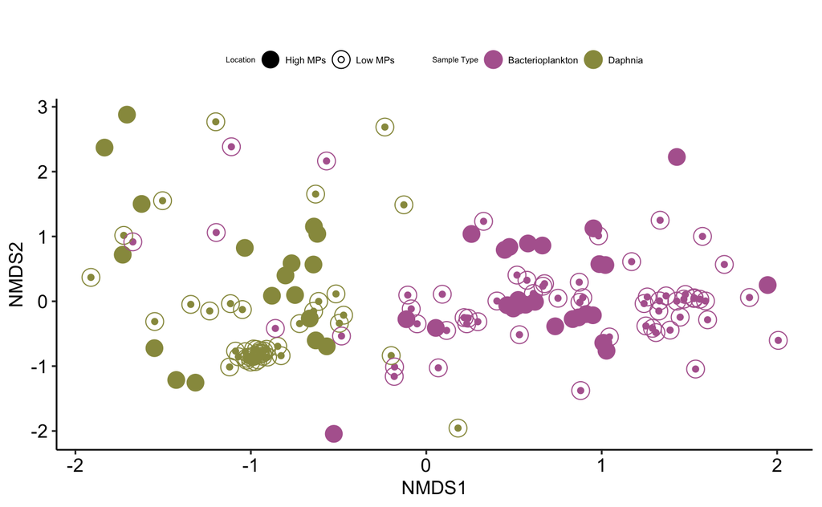

```r
sample_data(ps_filtered)$Category[sample_data(ps_filtered)$Category == "Artifical pond"] <- "High MPs"
sample_data(ps_filtered)$Category[sample_data(ps_filtered)$Category == "Natural pond"] <- "Low MPs"

colors = c("Bacterioplankton" = "#b3669e", "Daphnia" = "#98984d")
p = NULL
p = plot_ordination(ps_filtered, nMDS, color = "Type") +
  geom_point(aes(shape = Category), size = 5) +  # Increase point size here
  scale_color_manual(values = colors) +  # Apply custom color scheme
  scale_shape_manual(values = c(16,1,4)) +  # Custom shapes for each location
  labs(title = "",
       x = "NMDS1",
       y = "NMDS2",
       color = "Sample Type",
       shape = "Location") +  # Update labels
  theme_pubr()+  # Minimal theme
  theme(legend.text = element_text(size = 6),  # Smaller legend text
        legend.title = element_text(size = 5),  # Smaller legend title
        legend.key.size = unit(0.5, "cm"))  # Smaller legend keys
p
```

Statistical analysis(PERMANOVAS):

1. Is there a difference in a community between bacterioplankton and microbiome?

```r
bray <- vegdist(data.frame(t(otu_table(ps_filtered))), method="bray")
#permanova:
permanova = adonis2(bray ~ data.frame(sample_data(ps_filtered))$Type)
print(permanova)
```

```r
# test homogeneity of variance
homog_test_cat <- betadisper(bray, data.frame(sample_data(ps_filtered))$Type,bias.adjust=TRUE) #Calculate multivariate dispersions
disp_category=anova(homog_test_cat) #Perform test
print(disp_category)
```

““” BACTERIOPLANKTON ““” 1. Is there statistical difference between AP and NP in Bacterioplankton communities?

```r
#Load bacterioplantkon ps
ps_rarified_bac = readRDS("/Users/u0145079/Library/CloudStorage/OneDrive-KULeuven/Desktop/PlasticDaphnia/Field/Miseq/output/dada2/new/bac_rarified")
ps_filtered_bac <- prune_samples(sample_data(ps_rarified_bac)$Category != "WWTP", ps_rarified_bac) #remove WWTP
bray <- vegdist(data.frame(otu_table(ps_filtered_bac)), method="bray")

#Permanova_test
permanova = adonis2(bray ~ data.frame(sample_data(ps_filtered_bac))$Category)
print(permanova)
```

```
Permutation test for adonis under reduced model
Terms added sequentially (first to last)
Permutation: free
Number of permutations: 999

adonis2(formula = bray ~ data.frame(sample_data(ps_filtered_bac))$Category)
                                                  Df SumOfSqs      R2      F Pr(>F)
data.frame(sample_data(ps_filtered_bac))$Category  1   1.4977 0.04984 4.3012  0.001 ***
Residual                                          82  28.5528 0.95016
Total                                             83  30.0504 1.00000
---
Signif. codes:  0 ‘***’ 0.001 ‘**’ 0.01 ‘*’ 0.05 ‘.’ 0.1 ‘ ’ 1
```

```r
# test homogeneity of variance
homog_test_cat <- betadisper(bray, data.frame(sample_data(ps_filtered_bac))$Category,bias.adjust=TRUE) #Calculate multivariate dispersions
disp_category=anova(homog_test_cat) #0.07019
print(disp_category)
```

```
Analysis of Variance Table

Response: Distances
          Df  Sum Sq  Mean Sq F value  Pr(>F)
Groups     1 0.03654 0.036535  3.3658 0.07019 .
Residuals 82 0.89010 0.010855
---
Signif. codes:  0 ‘***’ 0.001 ‘**’ 0.01 ‘*’ 0.05 ‘.’ 0.1 ‘ ’ 1
```

Conclusion: There is a significant difference between bacterioplankton communities in AP and NP.